# HW #3

```python
import numpy as np
import pandas as pd
import matplotlib.pyplot as plt
```

## 1) 데이터프레임을 생성하고 데이터 살펴보기

```python
with open('HW3.csv') as f:
    for _ in range(3):
        print(f.readline())
```

```
,Income,Limit,Rating,Cards,Age,Education,Gender,Student,Married,Ethnicity,Balance

1,14.891,3606,283,2,34,11,Male,No,Yes,Caucasian,333

2,106.025,6645,483,3,82,15,Female,Yes,Yes,Asian,903
```

```python
df = pd.read_csv('HW3.csv', index_col=0)
```

```python
df.head(3)
```

|  | Income | Limit | Rating | Cards | Age | Education | Gender | Student | Married | Ethnicity | Balance |
| --- | --- | --- | --- | --- | --- | --- | --- | --- | --- | --- | --- |
| 1 | 14.891 | 3606 | 283 | 2 | 34 | 11 | Male | No | Yes | Caucasian | 333 |
| 2 | 106.025 | 6645 | 483 | 3 | 82 | 15 | Female | Yes | Yes | Asian | 903 |
| 3 | 104.593 | 7075 | 514 | 4 | 71 | 11 | Male | No | No | Asian | 580 |

```python
df.shape
```

```
(400, 11)
```

```python
df.info()
```

```
<class 'pandas.core.frame.DataFrame'>
Int64Index: 400 entries, 1 to 400
Data columns (total 11 columns):
 #   Column     Non-Null Count  Dtype
---  ------     --------------  -----
 0   Income     400 non-null    float64
 1   Limit      400 non-null    int64
 2   Rating     400 non-null    int64
 3   Cards      400 non-null    int64
 4   Age        400 non-null    int64
 5   Education  400 non-null    int64
 6   Gender     400 non-null    object
 7   Student    400 non-null    object
 8   Married    400 non-null    object
 9   Ethnicity  400 non-null    object
 10  Balance    400 non-null    int64
dtypes: float64(1), int64(6), object(4)
memory usage: 37.5+ KB
```

- 특성의 개수는 10개, 관측치는 400개 이며 결측치는 없다.
- 수치형 특성 : Income, Limit, Rating, Cards, Age, Education
- 범주형 특성 : Gender, Student, Married, Ethnicity

### ※참고 : 범주형 특성과 수치형 특성의 이름을 코드로 추출하는 방법

```python
feat = [name for name in df.columns if name != 'Balance']
feat
```

```
['Income',
 'Limit',
 'Rating',
 'Cards',
 'Age',
 'Education',
 'Gender',
 'Student',
 'Married',
 'Ethnicity']
```

```python
cat_feat = [name for name in feat if df[name].dtype == 'object']
cat_feat
```

```
['Gender', 'Student', 'Married', 'Ethnicity']
```

```python
num_feat = [name for name in feat if name not in cat_feat]
num_feat
```

```
['Income', 'Limit', 'Rating', 'Cards', 'Age', 'Education']
```

```python
#다음과 같이 set 연산을 하는 것도 가능하지만 변수의 순서는 유지되지 않으므로 추천하지 않음
num_feat = list(set(feat)-set(cat_feat))
num_feat
```

```
['Age', 'Cards', 'Rating', 'Education', 'Limit', 'Income']
```

## 2) 차트 그리기

### 방법 1 : 하나씩 그리기

#### 아래 과정을 모든 수치형 특성에 대하여 반복하기

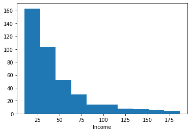

```python
plt.hist(df.Income)
plt.xlabel('Income');
```

#### 아래 과정을 모든 범주형 특성에 대하여 반복하기

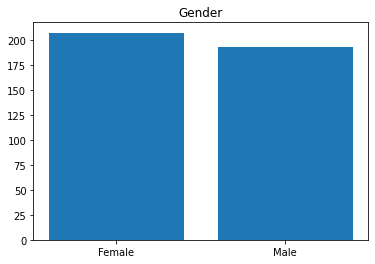

```python
counts = df.Gender.value_counts()
plt.bar(counts.index, counts.values)
plt.title('Gender');
```

### 방법 2 : 반복문과 plt.subplot()을 사용하여 한꺼번에 그리기

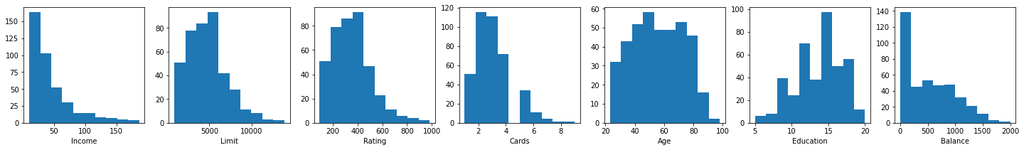

```python
plt.figure(figsize=(25,3))
for i in range(6):
    plt.subplot(1, 7, i+1)
    plt.hist(df.iloc[:, i])
    plt.xlabel(df.columns[i])
plt.subplot(1, 7, 7)
plt.hist(df.iloc[:, 10])
plt.xlabel(df.columns[10]);
```

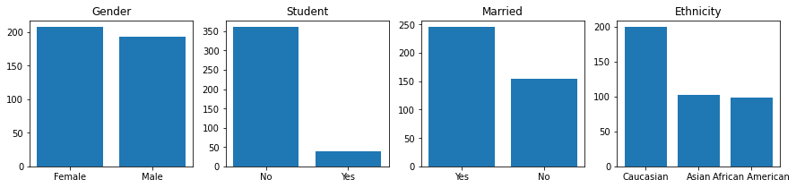

```python
plt.figure(figsize=(15,3))
for i in range(6,10):
    counts = pd.Series(df.iloc[:, i]).value_counts()
    plt.subplot(1, 4, i-5)
    plt.bar(counts.index, counts.values)
    plt.title(df.columns[i])
```

### 방법 3 : 특성 이름 배열을 사용하여 한꺼번에 그리기

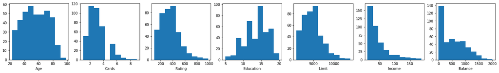

```python
cols = num_feat + ['Balance']
plt.figure(figsize=(25,3))
i = 1
for name in cols:
    plt.subplot(1, 7, i)
    plt.hist(df[name])
    plt.xlabel(name)
    i = i + 1
```

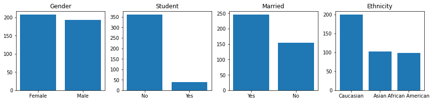

```python
plt.figure(figsize=(15,3))
i = 1
for name in cat_feat:
    counts = df[name].value_counts()
    plt.subplot(1, 4, i)
    plt.bar(counts.index, counts.values)
    plt.title(name)
    i += 1
```

- 수치형 변수의 히스토그램 : Education과 Age를 제외한 대부분의 특성이 현저히 왼쪽으로 치우쳐 있다. Balance는 특히 왼쪽으로 많이 치우쳐 잔고가 거의 0인 고객들이 아주 많다.
- 범주형 변수의 막대그래프 : 학생이 아닌 고객이 대부분이다.

## 3) 상관관계 파악하기

```python
df.corr()
```

|  | Income | Limit | Rating | Cards | Age | Education | Balance |
| --- | --- | --- | --- | --- | --- | --- | --- |
| Income | 1.000000 | 0.792088 | 0.791378 | -0.018273 | 0.175338 | -0.027692 | 0.463656 |
| Limit | 0.792088 | 1.000000 | 0.996880 | 0.010231 | 0.100888 | -0.023549 | 0.861697 |
| Rating | 0.791378 | 0.996880 | 1.000000 | 0.053239 | 0.103165 | -0.030136 | 0.863625 |
| Cards | -0.018273 | 0.010231 | 0.053239 | 1.000000 | 0.042948 | -0.051084 | 0.086456 |
| Age | 0.175338 | 0.100888 | 0.103165 | 0.042948 | 1.000000 | 0.003619 | 0.001835 |
| Education | -0.027692 | -0.023549 | -0.030136 | -0.051084 | 0.003619 | 1.000000 | -0.008062 |
| Balance | 0.463656 | 0.861697 | 0.863625 | 0.086456 | 0.001835 | -0.008062 | 1.000000 |

- Limit와 Rating은 강한 양의 상관관계를 보인다. (Limit는 신용한도, Rating은 신용점수이므로 당연한 결과)
- Income과 Limit, Income과 Rating도 강한 양의 상관관계를 보인다.
- 레이블인 Balance와 상관관계가 높은 변수는 Limit와 Rating이다.

## 4) 수치형 특성과 레이블 산점도 그리기

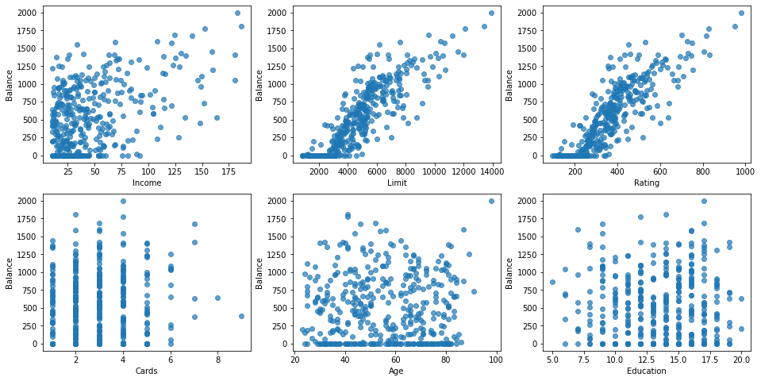

```python
plt.figure(figsize=(16,8))
for i in range(1, 7):
    plt.subplot(2,3,i)
    plt.scatter(df.iloc[:,i-1], df.iloc[:, 10], alpha=0.7)
    plt.xlabel(df.columns[i-1])
    plt.ylabel(df.columns[10])
```

## 5) Rating으로 Balance를 설명하는 단순선형회귀

※ 해당 칼럼을 추출한 후, X와 y 모두 판다스 Series 그대로 사용해도 무관하지만 넘파이 배열로 변환함, 그리고 X는 2차원 배열로 반드시 변환해야 함

```python
X = df.loc[:, 'Rating'].to_numpy()  # X = df.loc[:, 'Rating'].values()
```

```python
X = X[:, np.newaxis]  # X = X.reshape(X.shape[0], 1)와 동일
X.shape
```

```
(400, 1)
```

```python
y = df['Balance'].to_numpy()   #y = df['Balance'].values()
```

```python
from sklearn.linear_model import LinearRegression
```

```python
reg1 = LinearRegression()
```

```python
reg1.fit(X, y)
```

```
LinearRegression()
```

```python
reg1.coef_
```

```
array([2.56624033])
```

```python
reg1.intercept_
```

```
-390.8463417872375
```

```python
pred = reg1.predict(X)
```

```python
score = reg1.score(X, y)
```

```python
score
```

```
0.7458484180585037
```

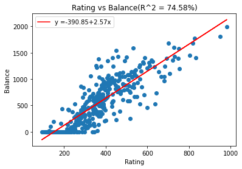

```python
plt.scatter(X, y)
plt.xlabel('Rating')
plt.ylabel('Balance')
eq = 'y =' + str(round(reg1.intercept_,2)) + '+' +str(round(reg1.coef_[0],2)) + 'x'
plt.plot(X, pred, color='red', label=eq)
plt.title('Rating vs Balance' + '(R^2 = '+ str(round(score,4)*100) + '%)')
plt.legend();
```

## 6) 모든 수치형 특성으로 Balance를 설명하는 선형회귀

```python
X = df.iloc[:, :6].values  #X = df.loc[:,:'Education']
```

```python
y = df['Balance'].values
```

```python
from sklearn.model_selection import train_test_split
```

```python
X_train, X_test, y_train, y_test = train_test_split(X, y, train_size=0.7, random_state=0)
```

```python
reg2 = LinearRegression()
```

```python
reg2.fit(X_train, y_train)
```

```
LinearRegression()
```

```python
reg2.coef_
```

```
array([-7.90523312,  0.15976222,  1.56900826, 14.42490726, -0.60836095,
        2.94113733])
```

```python
reg2.intercept_
```

```
-486.6594364191827
```

```python
reg2.score(X_train, y_train)
```

```
0.8857073035585357
```

```python
reg2.score(X_test, y_test)
```

```
0.8557914117915563
```

- 훈련데이터에 대한 결정계수가 0.8857로서 비교적 1에 가까우므로 과소적합이라고 할 수 없다. 또한 테스트셋에 대한 결정계수가 트레이닝셋에 대한 결정계수와 크게 차이가 나지 않으므로 과대적합은 아니라고 할 수 있다.
- 다만, Limit 특성과 Rating 특성이 거의 유사한 특성이므로 회귀모형에 두 특성 중 하나만 포함시킨 조금 더 단순한 모형을 고려해 볼 수는 있다.

※ predict 메서드는 2차원 배열(혹은 리스트)을 인수로 하므로 주의=>아래 두 방법 중 하나 사용

```python
new_case = [[100, 6000, 550, 5, 55, 20]]
reg2.predict(new_case)
```

```
array([641.83257176])
```

```python
new_ex = [100, 6000, 550, 5, 55, 20]
new_case = np.array(new_ex).reshape(1,6)
reg2.predict(new_case)
```

```
array([641.83257176])
```

```python
reg2.intercept_+np.dot(reg2.coef_, new_ex)  #선형회귀식을 이용한 예측의 의미
```

```
641.8325717615611
```